# Puerto Rico Remote Sensing - Belowground

# Resin P Analysis

Pre-hurricane analysis of resin P on sites SB2 and EV1. Collected and processed March 2017.

```r
library(tidyverse)
resinp <- read.csv("~/Documents/LabStats/PR2_RemoteSensing/ResinP_2017.csv", header = TRUE, stringsAsFactors = TRUE, na.strings = "NA") # units = ugP/g soil dry weight
```

## Resin P Summary Stats

### Resin P at SB2 and EV1

```r
# resin p mean, sd, and se by site
resinp %>%
  group_by(Site) %>%
  summarise(
     n = n(),
    mean = mean(ResinP, na.rm = TRUE),
    sd = sd(ResinP, na.rm = TRUE),
    se = (sd(ResinP, na.rm = TRUE)/(sqrt(n()))))
```

| Site | n | mean | sd | se |
| --- | --- | --- | --- | --- |
| EV1 | 9 | 0.1385556 | 0.2173144 | 0.07243812 |
| SB2 | 11 | 0.8740000 | 0.7578679 | 0.22850578 |

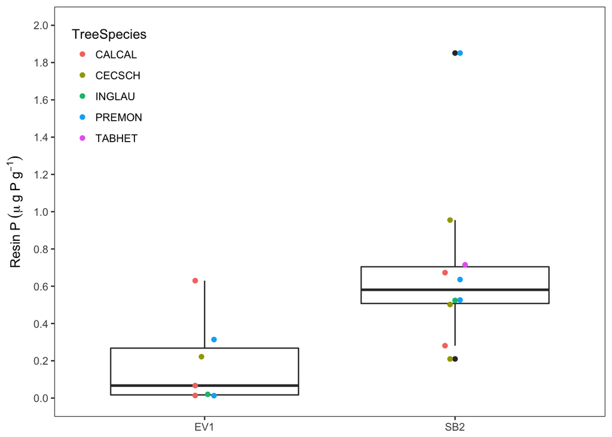

```r
# graph
ticks <- seq(0, 2, by = 0.20)

ggplot(data = resinp, aes(x = Site, y = ResinP)) + geom_boxplot() + geom_point(aes(x = Site, y = ResinP, colour = TreeSpecies), position = position_dodge(0.1)) + scale_y_continuous(limits = c(0,2), breaks = ticks) + theme_bw() + theme(
  panel.grid.major = element_blank(),
  panel.grid.minor = element_blank(),
  axis.title.x = element_blank(),
  legend.position = c(0.1,0.8)) + ylab((expression(Resin~P~(mu~g~P~g^{-1}))))
```

### Resin P near tree species’ at SB2 and EV1

```r
# resin p mean, sd, and se by site x tree species
resinp %>%
  group_by(Site, TreeSpecies) %>%
  summarise(
     n = n(),
    mean = mean(ResinP, na.rm = TRUE),
    sd_total = sd(ResinP, na.rm = TRUE),
    se_total = (sd(ResinP, na.rm = TRUE)/(sqrt(n()))))
```

| Site | TreeSpecies | n | mean | sd_total | se_total |
| --- | --- | --- | --- | --- | --- |
| EV1 | CALCAL | 3 | 0.2370000 | 0.3413781 | 0.1970947 |
| EV1 | CECSCH | 2 | 0.1020000 | 0.1697056 | 0.1200000 |
| EV1 | INGLAU | 1 | 0.0200000 | NA | NA |
| EV1 | PREMON | 3 | 0.1040000 | 0.1824034 | 0.1053107 |
| SB2 | CALCAL | 3 | 1.2316667 | 1.3217342 | 0.7631036 |
| SB2 | CECSCH | 3 | 0.5556667 | 0.3753882 | 0.2167305 |
| SB2 | INGLAU | 1 | 0.5240000 | NA | NA |
| SB2 | PREMON | 3 | 1.0043333 | 0.7352947 | 0.4245226 |
| SB2 | TABHET | 1 | 0.7150000 | NA | NA |

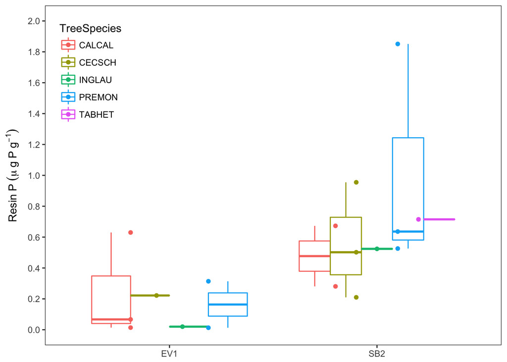

```r
# graph
ggplot(data = resinp, aes(x = Site, y = ResinP, colour = TreeSpecies), position_dodge(position_dodge(0.5))) + geom_boxplot() + geom_point(aes(x = Site, y = ResinP, colour = TreeSpecies), position = position_dodge(0.5)) + scale_y_continuous(limits = c(0,2), breaks = ticks) + theme_bw() + theme(
  panel.grid.major = element_blank(),
  panel.grid.minor = element_blank(),
  axis.title.x = element_blank(),
  legend.position = c(0.1,0.8)) + ylab((expression(Resin~P~(mu~g~P~g^{-1}))))
```

Resin P is highest at SB2 (0.874 +/- 0.758) relative to EV1 (0.139 +/- 0.217), consistent with the highest resin P averages near CALCAL and PREMON trees in SB2. When comparing the same tree species across the two sites, resin p values near trees at SB2 are consistently higher.

## Resin P ANOVA

```r
resinp.aov <- aov(ResinP ~ Site + TreeSpecies + Site*TreeSpecies, data = resinp)
summary(resinp.aov)
```

```
##                  Df Sum Sq Mean Sq F value Pr(>F)
## Site              1  2.677  2.6773   5.679 0.0363 *
## TreeSpecies       4  0.679  0.1698   0.360 0.8318
## Site:TreeSpecies  3  0.257  0.0855   0.181 0.9068
## Residuals        11  5.186  0.4714
## ---
## Signif. codes:  0 '***' 0.001 '**' 0.01 '*' 0.05 '.' 0.1 ' ' 1
```

```r
TukeyHSD(resinp.aov)
```

```
##   Tukey multiple comparisons of means
##     95% family-wise confidence level
##
## Fit: aov(formula = ResinP ~ Site + TreeSpecies + Site * TreeSpecies, data = resinp)
##
## $Site
##              diff        lwr      upr     p adj
## SB2-EV1 0.7354444 0.05621762 1.414671 0.0362981
##
## $TreeSpecies
##                      diff       lwr       upr     p adj
## CECSCH-CALCAL -0.43367778 -1.778234 0.9108781 0.8305290
## INGLAU-CALCAL -0.46233333 -2.275332 1.3506655 0.9174550
## PREMON-CALCAL -0.18016667 -1.462150 1.1018171 0.9899556
## TABHET-CALCAL -0.38705556 -2.785428 2.0113164 0.9832189
## INGLAU-CECSCH -0.02865556 -1.886426 1.8291154 0.9999983
## PREMON-CECSCH  0.25351111 -1.091045 1.5980670 0.9705390
## TABHET-CECSCH  0.04662222 -2.385771 2.4790153 0.9999961
## PREMON-INGLAU  0.28216667 -1.530832 2.0951655 0.9853165
## TABHET-INGLAU  0.07527778 -2.644220 2.7947760 0.9999829
## TABHET-PREMON -0.20688889 -2.605261 2.1914831 0.9984560
##
## $`Site:TreeSpecies`
##                              diff       lwr      upr     p adj
## SB2:CALCAL-EV1:CALCAL  0.99466667 -1.180145 3.169478 0.7384063
## EV1:CECSCH-EV1:CALCAL -0.13500000 -2.566513 2.296513 0.9999999
## SB2:CECSCH-EV1:CALCAL  0.31866667 -1.856145 2.493478 0.9997788
## EV1:INGLAU-EV1:CALCAL -0.21700000 -3.292648 2.858648 0.9999995
## SB2:INGLAU-EV1:CALCAL  0.28700000 -2.788648 3.362648 0.9999949
## EV1:PREMON-EV1:CALCAL -0.13300000 -2.307811 2.041811 0.9999999
## SB2:PREMON-EV1:CALCAL  0.76733333 -1.407478 2.942145 0.9141830
## EV1:TABHET-EV1:CALCAL          NA        NA       NA        NA
## SB2:TABHET-EV1:CALCAL  0.47800000 -2.597648 3.553648 0.9996461
## EV1:CECSCH-SB2:CALCAL -1.12966667 -3.561180 1.301846 0.7235372
## SB2:CECSCH-SB2:CALCAL -0.67600000 -2.850811 1.498811 0.9563034
## EV1:INGLAU-SB2:CALCAL -1.21166667 -4.287314 1.863981 0.8557709
## SB2:INGLAU-SB2:CALCAL -0.70766667 -3.783314 2.367981 0.9934156
## EV1:PREMON-SB2:CALCAL -1.12766667 -3.302478 1.047145 0.6086660
## SB2:PREMON-SB2:CALCAL -0.22733333 -2.402145 1.947478 0.9999865
## EV1:TABHET-SB2:CALCAL          NA        NA       NA        NA
```

[output cut: 14 more lines]

```
## SB2:INGLAU-EV1:INGLAU  0.50400000 -3.262884 4.270884 0.9998941
## EV1:PREMON-EV1:INGLAU  0.08400000 -2.991648 3.159648 1.0000000
## SB2:PREMON-EV1:INGLAU  0.98433333 -2.091314 4.059981 0.9485888
## EV1:TABHET-EV1:INGLAU          NA        NA       NA        NA
## SB2:TABHET-EV1:INGLAU  0.69500000 -3.071884 4.461884 0.9986646
## EV1:PREMON-SB2:INGLAU -0.42000000 -3.495648 2.655648 0.9998749
## SB2:PREMON-SB2:INGLAU  0.48033333 -2.595314 3.555981 0.9996322
## EV1:TABHET-SB2:INGLAU          NA        NA       NA        NA
## SB2:TABHET-SB2:INGLAU  0.19100000 -3.575884 3.957884 1.0000000
## SB2:PREMON-EV1:PREMON  0.90033333 -1.274478 3.075145 0.8217519
## EV1:TABHET-EV1:PREMON          NA        NA       NA        NA
## SB2:TABHET-EV1:PREMON  0.61100000 -2.464648 3.686648 0.9976853
## EV1:TABHET-SB2:PREMON          NA        NA       NA        NA
## SB2:TABHET-SB2:PREMON -0.28933333 -3.364981 2.786314 0.9999945
## SB2:TABHET-EV1:TABHET          NA        NA       NA        NA
```

As expected, resin P differed significantly between EV1 and SB2 (p-value < 0.05), driven only by site. Tukey HSD shows that there were no significant differences between tree species within and among sites.

# Organic Phosphorus

Organic phosphorus results from SB2 and EV1 from March 2017 Puerto Rico sampling trip.

```r
organicp <- read.csv("~/Documents/LabStats/PR2_RemoteSensing/RemoteSensing_OrganicP.csv", header = TRUE, na.strings = "NA", stringsAsFactors = TRUE)
```

## Acid organic phosphorus

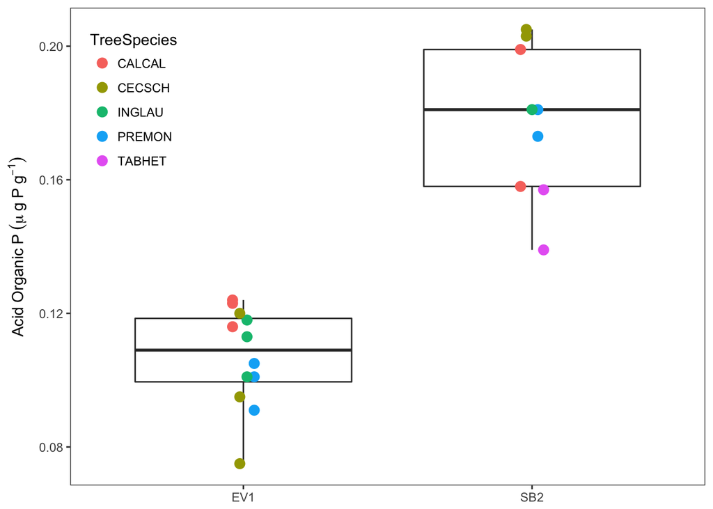

```r
ggplot(data = organicp, aes(x = Site, y = Acid)) + geom_boxplot() + geom_point(aes(x = Site, y = Acid, colour = TreeSpecies), position = position_dodge(0.1), size = 3.0) + theme_bw() + theme(
  panel.grid.major = element_blank(),
  panel.grid.minor = element_blank(),
  axis.title.x = element_blank(),
  legend.position = c(0.1,0.8)) + ylab((expression(Acid~Organic~P~(mu~g~P~g^{-1}))))
```

## Alkaline organic phosphorus

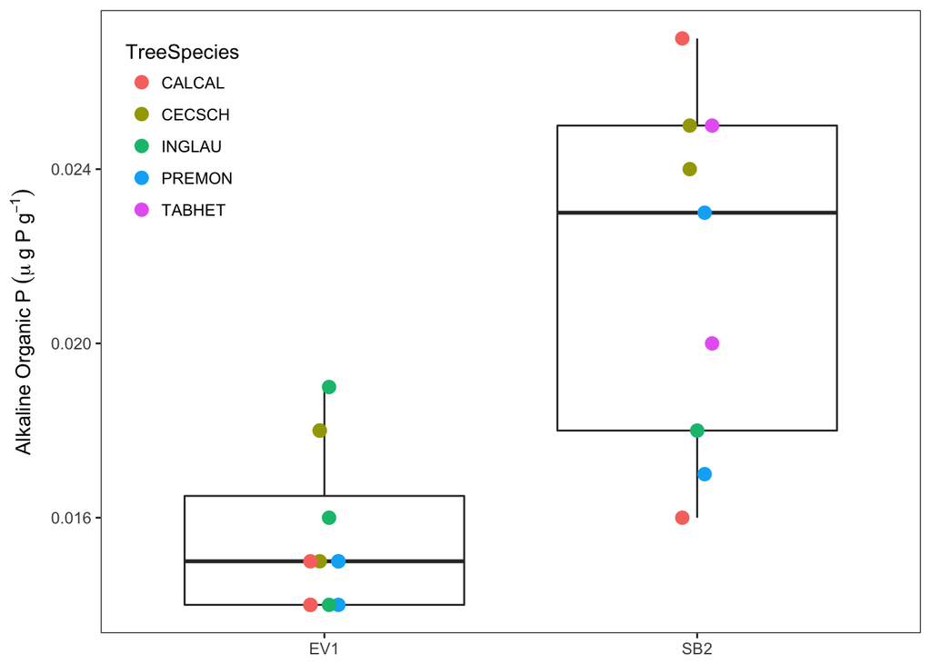

```r
ggplot(data = organicp, aes(x = Site, y = Alkaline)) + geom_boxplot() + geom_point(aes(x = Site, y = Alkaline, colour = TreeSpecies), position = position_dodge(0.1), size = 3.0) + theme_bw() + theme(
  panel.grid.major = element_blank(),
  panel.grid.minor = element_blank(),
  axis.title.x = element_blank(),
  legend.position = c(0.1,0.8)) + ylab((expression(Alkaline~Organic~P~(mu~g~P~g^{-1}))))
```

## Total organic phosphorus

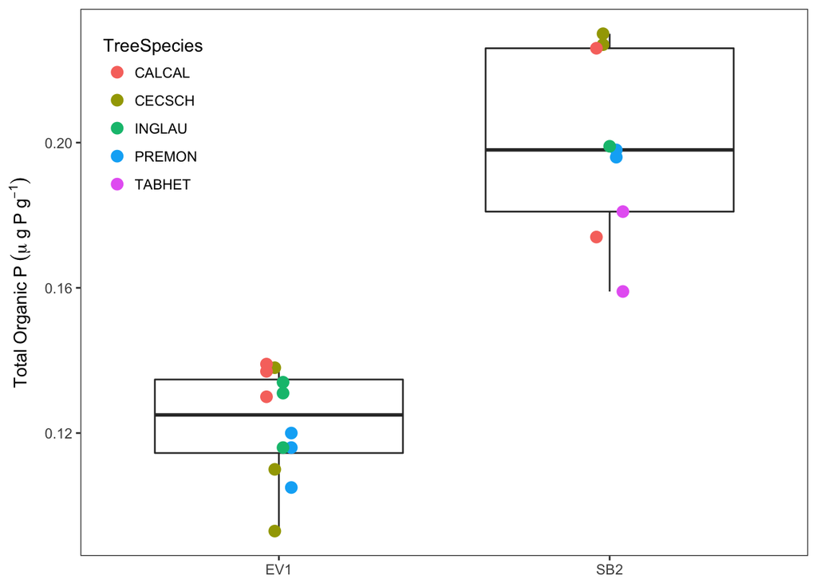

```r
ggplot(data = organicp, aes(x = Site, y = Total)) + geom_boxplot() + geom_point(aes(x = Site, y = Total, colour = TreeSpecies), position = position_dodge(0.1), size = 3.0) + theme_bw() + theme(
  panel.grid.major = element_blank(),
  panel.grid.minor = element_blank(),
  axis.title.x = element_blank(),
  legend.position = c(0.1,0.8)) + ylab((expression(Total~Organic~P~(mu~g~P~g^{-1}))))
```

```r
organicp.siteaov <- aov(Total ~ Site, data = organicp)
summary(organicp.siteaov)
```

```
##             Df  Sum Sq  Mean Sq F value   Pr(>F)
## Site         1 0.03008 0.030075   76.81 4.21e-08 ***
## Residuals   19 0.00744 0.000392
## ---
## Signif. codes:  0 '***' 0.001 '**' 0.01 '*' 0.05 '.' 0.1 ' ' 1
```

Total organic phosphorus is the sum of acid and alkaline extracted phosphorus. Acid extracted organic phosphorus comprised the majority of the total organic phosphorus at both EV1 and SB2, with significantly (p-value < 0.001) higher amounts of organic P at SB2 (mean = 7.85 mgP/L) relative to EV1 (mean = 4.98 mgP/L).

## Average organic phosphorus at each site

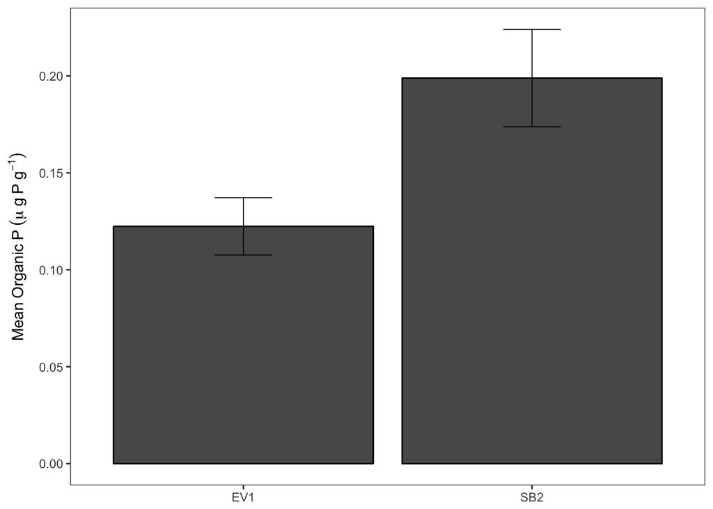

```r
organicp.sum <- organicp %>%
  group_by(Site) %>%
  summarise(
    n = n(),
    mean_total = mean(Total, na.rm = TRUE),
    sd_total = sd(Total, na.rm = TRUE),
    se_total = (sd(Total, na.rm = TRUE)/(sqrt(n()))))
View(organicp.sum)

ggplot(data = organicp.sum, aes(x = Site, y = mean_total)) + geom_bar(stat = "identity", colour = "black") + geom_errorbar(aes(ymax=mean_total+sd_total, ymin=mean_total-sd_total), width = 0.2, size = 0.3) + theme_bw() + theme(
  panel.grid.major = element_blank(),
  panel.grid.minor = element_blank(),
  axis.title.x = element_blank(),
  legend.position = c(0.1,0.8)) + ylab((expression(Mean~Organic~P~(mu~g~P~g^{-1}))))
```

## Organic phosphorus by site and tree species

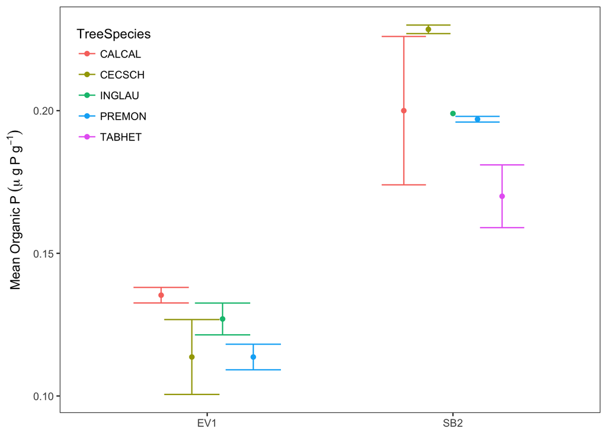

```r
organicp.sum2 <- organicp %>%
  group_by(Site, TreeSpecies) %>%
  summarise(
    n = n(),
    mean_total = mean(Total, na.rm = TRUE),
    sd_total = sd(Total, na.rm = TRUE),
    se_total = (sd(Total, na.rm = TRUE)/(sqrt(n()))))
View(organicp.sum2)

ggplot(data = organicp.sum2, aes(x = Site, y = mean_total, colour = TreeSpecies)) + geom_point(position = position_dodge(0.5)) + geom_errorbar(aes(ymax=mean_total+se_total, ymin=mean_total-se_total), position = position_dodge(0.5)) + theme_bw() + theme(
  panel.grid.major = element_blank(),
  panel.grid.minor = element_blank(),
  axis.title.x = element_blank(),
  legend.position = c(0.1,0.8)) + ylab((expression(Mean~Organic~P~(mu~g~P~g^{-1}))))
```

```r
organicp.sitespecies.aov <- aov(Total ~ Site * TreeSpecies, data = organicp)
summary(organicp.sitespecies.aov)
```

```
##                  Df   Sum Sq  Mean Sq F value   Pr(>F)
## Site              1 0.030075 0.030075 120.927 1.27e-07 ***
## TreeSpecies       4 0.002761 0.000690   2.775   0.0763 .
## Site:TreeSpecies  3 0.001694 0.000565   2.271   0.1325
## Residuals        12 0.002985 0.000249
## ---
## Signif. codes:  0 '***' 0.001 '**' 0.01 '*' 0.05 '.' 0.1 ' ' 1
```

```r
TukeyHSD(organicp.sitespecies.aov)
```

```
##   Tukey multiple comparisons of means
##     95% family-wise confidence level
##
## Fit: aov(formula = Total ~ Site * TreeSpecies, data = organicp)
##
## $Site
##               diff        lwr        upr p adj
## SB2-EV1 0.07647222 0.06132047 0.09162397 1e-07
##
## $TreeSpecies
##                       diff         lwr         upr     p adj
## CECSCH-CALCAL -0.001600000 -0.03339187 0.030191874 0.9998277
## INGLAU-CALCAL -0.004729167 -0.03844954 0.028991208 0.9906577
## PREMON-CALCAL -0.014200000 -0.04599187 0.017591874 0.6253320
## TABHET-CALCAL -0.037083333 -0.07914003 0.004973363 0.0940044
## INGLAU-CECSCH -0.003129167 -0.03684954 0.030591208 0.9980831
## PREMON-CECSCH -0.012600000 -0.04439187 0.019191874 0.7168816
## TABHET-CECSCH -0.035483333 -0.07754003 0.006573363 0.1145661
## PREMON-INGLAU -0.009470833 -0.04319121 0.024249541 0.8932705
## TABHET-INGLAU -0.032354167 -0.07588698 0.011178650 0.1895240
## TABHET-PREMON -0.022883333 -0.06494003 0.019173363 0.4506964
##
## $`Site:TreeSpecies`
##                                diff          lwr          upr     p adj
## SB2:CALCAL-EV1:CALCAL  6.466667e-02  0.009750627  0.119582706 0.0168206
## EV1:CECSCH-EV1:CALCAL -2.166667e-02 -0.070785065  0.027451732 0.7863789
## SB2:CECSCH-EV1:CALCAL  9.316667e-02  0.038250627  0.148082706 0.0008254
## EV1:INGLAU-EV1:CALCAL -8.333333e-03 -0.057451732  0.040785065 0.9994190
## SB2:INGLAU-EV1:CALCAL  6.366667e-02 -0.005797239  0.133130572 0.0829593
## EV1:PREMON-EV1:CALCAL -2.166667e-02 -0.070785065  0.027451732 0.7863789
## SB2:PREMON-EV1:CALCAL  6.166667e-02  0.006750627  0.116582706 0.0235110
## EV1:TABHET-EV1:CALCAL            NA           NA           NA        NA
## SB2:TABHET-EV1:CALCAL  3.466667e-02 -0.020249373  0.089582706 0.3959004
## EV1:CECSCH-SB2:CALCAL -8.633333e-02 -0.141249373 -0.031417294 0.0016406
## SB2:CECSCH-SB2:CALCAL  2.850000e-02 -0.031657507  0.088657507 0.7214052
## EV1:INGLAU-SB2:CALCAL -7.300000e-02 -0.127916039 -0.018083961 0.0067145
## SB2:INGLAU-SB2:CALCAL -1.000000e-03 -0.074677598  0.072677598 1.0000000
## EV1:PREMON-SB2:CALCAL -8.633333e-02 -0.141249373 -0.031417294 0.0016406
## SB2:PREMON-SB2:CALCAL -3.000000e-03 -0.063157507  0.057157507 1.0000000
## EV1:TABHET-SB2:CALCAL            NA           NA           NA        NA
```

[output cut: 14 more lines]

```
## SB2:INGLAU-EV1:INGLAU  7.200000e-02  0.002536094  0.141463906 0.0399792
## EV1:PREMON-EV1:INGLAU -1.333333e-02 -0.062451732  0.035785065 0.9830750
## SB2:PREMON-EV1:INGLAU  7.000000e-02  0.015083961  0.124916039 0.0093209
## EV1:TABHET-EV1:INGLAU            NA           NA           NA        NA
## SB2:TABHET-EV1:INGLAU  4.300000e-02 -0.011916039  0.097916039 0.1807072
## EV1:PREMON-SB2:INGLAU -8.533333e-02 -0.154797239 -0.015869428 0.0123320
## SB2:PREMON-SB2:INGLAU -2.000000e-03 -0.075677598  0.071677598 1.0000000
## EV1:TABHET-SB2:INGLAU            NA           NA           NA        NA
## SB2:TABHET-SB2:INGLAU -2.900000e-02 -0.102677598  0.044677598 0.8683784
## SB2:PREMON-EV1:PREMON  8.333333e-02  0.028417294  0.138249373 0.0022355
## EV1:TABHET-EV1:PREMON            NA           NA           NA        NA
## SB2:TABHET-EV1:PREMON  5.633333e-02  0.001417294  0.111249373 0.0426914
## EV1:TABHET-SB2:PREMON            NA           NA           NA        NA
## SB2:TABHET-SB2:PREMON -2.700000e-02 -0.087157507  0.033157507 0.7715385
## SB2:TABHET-EV1:TABHET            NA           NA           NA        NA
```

When tree species is taken into account, site is still the main driver of organic phosphorus availability (p-value < 0.001) though tree species may play a slight role (p-value < 0.1).

# Root phosphatase activity

```r
pase <- read.csv("~/Documents/LabStats/PR2_RemoteSensing/RemoteSensing_Pase.csv", header = TRUE, stringsAsFactors = TRUE, na.strings = "NA")
```

## Root phosphatase by site

```r
pase %>%
  group_by(Site) %>%
  summarise(
     n = n(),
    mean = mean(Pase, na.rm = TRUE),
    sd_total = sd(Pase, na.rm = TRUE),
    se_total = (sd(Pase, na.rm = TRUE)/(sqrt(n()))))
```

| Site | n | mean | sd_total | se_total |
| --- | --- | --- | --- | --- |
| EV1 | 11 | 281.1100 | 117.27157 | 35.35871 |
| SB2 | 13 | 172.6992 | 98.71699 | 27.37917 |

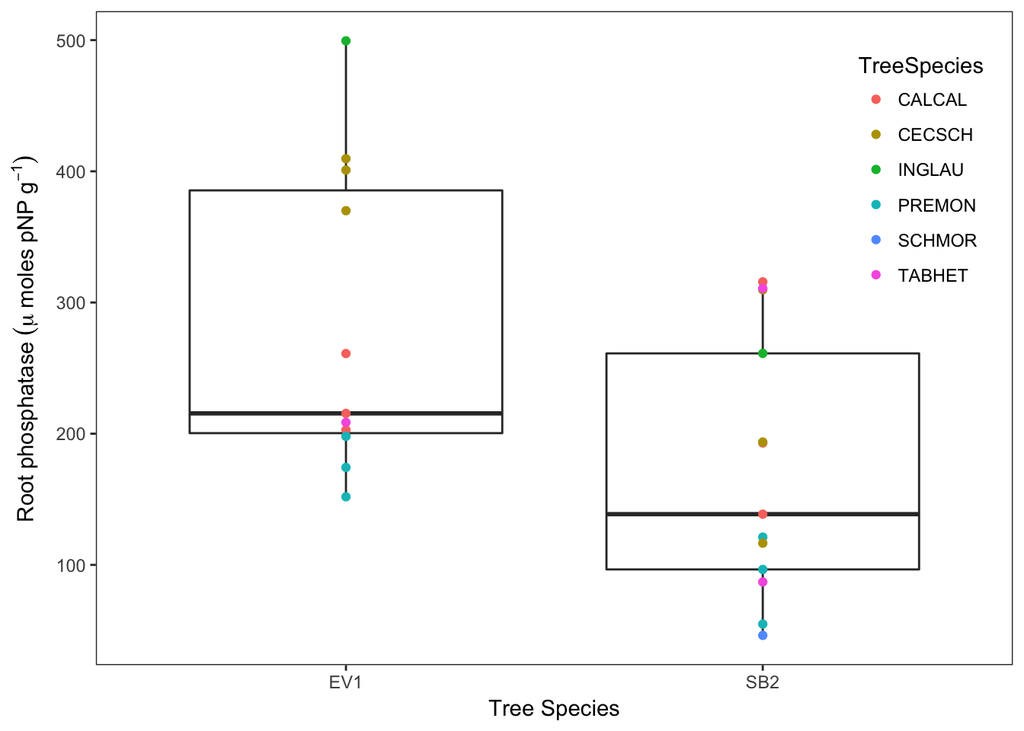

```r
# graph
ggplot(data = pase, aes(x = Site, y = Pase)) + geom_boxplot() + geom_point(aes(x = Site, y = Pase, colour = TreeSpecies)) + theme_bw() + theme(panel.grid.major = element_blank(), panel.grid.minor = element_blank()) + xlab("Tree Species") + ylab(expression(Root~phosphatase~(mu~moles~pNP~g^{-1}))) + theme(legend.position = c(0.9,0.75))
```

## Root phosphatase by site & tree species

```r
pase %>%
  group_by(Site, TreeSpecies) %>%
  summarise(
     n = n(),
    mean = mean(Pase, na.rm = TRUE),
    sd_total = sd(Pase, na.rm = TRUE),
    se_total = (sd(Pase, na.rm = TRUE)/(sqrt(n()))))
```

| Site | TreeSpecies | n | mean | sd_total | se_total |
| --- | --- | --- | --- | --- | --- |
| EV1 | CALCAL | 3 | 226.4833 | 30.62731 | 17.68269 |
| EV1 | CECSCH | 3 | 393.5067 | 20.83179 | 12.02724 |
| EV1 | INGLAU | 1 | 499.4300 | NA | NA |
| EV1 | PREMON | 3 | 174.7233 | 23.03335 | 13.29831 |
| EV1 | TABHET | 1 | 208.6400 | NA | NA |
| SB2 | CALCAL | 3 | 215.7867 | 90.71704 | 52.37551 |
| SB2 | CECSCH | 3 | 206.6300 | 97.21211 | 56.12544 |
| SB2 | INGLAU | 1 | 261.2100 | NA | NA |
| SB2 | PREMON | 3 | 90.8700 | 33.49686 | 19.33942 |
| SB2 | SCHMOR | 1 | 46.2700 | NA | NA |

[output cut: 1 more lines]

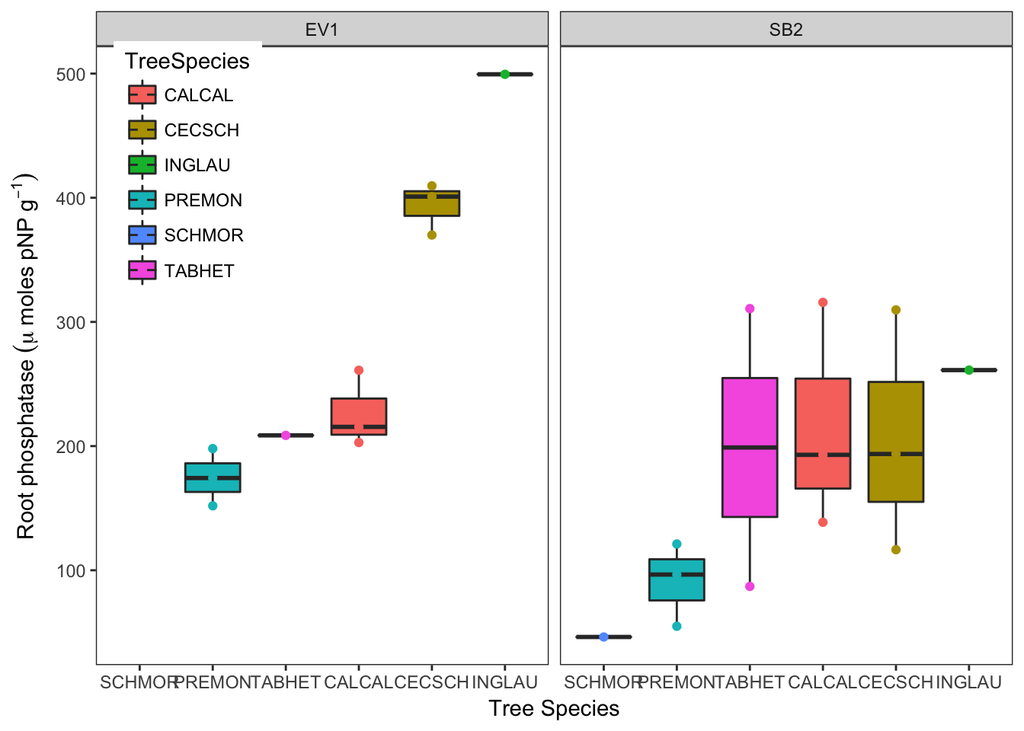

```r
# graph
ggplot(data = pase, aes(x = reorder(TreeSpecies, Pase, FUN = median), y = Pase, fill = TreeSpecies)) + geom_boxplot() + geom_point(aes(x = TreeSpecies, y = Pase, colour = TreeSpecies)) + facet_grid(. ~ Site) + theme_bw() + theme(panel.grid.major = element_blank(), panel.grid.minor = element_blank()) + xlab("Tree Species") + ylab(expression(Root~phosphatase~(mu~moles~pNP~g^{-1}))) + theme(legend.position = c(0.1,0.8))
```

## Root phoosphatase ANOVA

```r
rootpase.aov <- aov(Pase ~ Site + TreeSpecies + Site*TreeSpecies, data = pase)
summary(rootpase.aov)
```

```
##                  Df Sum Sq Mean Sq F value  Pr(>F)
## Site              1  70028   70028  13.701 0.00266 **
## TreeSpecies       5 149429   29886   5.847 0.00481 **
## Site:TreeSpecies  4  38593    9648   1.888 0.17268
## Residuals        13  66445    5111
## ---
## Signif. codes:  0 '***' 0.001 '**' 0.01 '*' 0.05 '.' 0.1 ' ' 1
```

```r
TukeyHSD(rootpase.aov)
```

```
##   Tukey multiple comparisons of means
##     95% family-wise confidence level
##
## Fit: aov(formula = Pase ~ Site + TreeSpecies + Site * TreeSpecies, data = pase)
##
## $Site
##              diff       lwr       upr     p adj
## SB2-EV1 -108.4108 -171.6848 -45.13673 0.0026626
##
## $TreeSpecies
##                       diff        lwr       upr     p adj
## CECSCH-CALCAL   78.9333333  -57.94329 215.80996 0.4368900
## INGLAU-CALCAL  159.1850000  -34.38778 352.75778 0.1351443
## PREMON-CALCAL  -88.3383333 -225.21496  48.53829 0.3261490
## SCHMOR-CALCAL -120.6596154 -376.73234 135.41310 0.6341474
## TABHET-CALCAL   -0.9365385 -168.57548 166.70241 1.0000000
## INGLAU-CECSCH   80.2516667 -113.32111 273.82445 0.7405035
## PREMON-CECSCH -167.2716667 -304.14829 -30.39504 0.0136644
## SCHMOR-CECSCH -199.5929487 -455.66567  56.47977 0.1695698
## TABHET-CECSCH  -79.8698718 -247.50882  87.76907 0.6240488
## PREMON-INGLAU -247.5233333 -441.09611 -53.95055 0.0098082
## SCHMOR-INGLAU -279.8446154 -570.20379  10.51456 0.0615535
## TABHET-INGLAU -160.1215385 -376.54249  56.29941 0.2076620
## SCHMOR-PREMON  -32.3212821 -288.39400 223.75144 0.9979515
## TABHET-PREMON   87.4017949  -80.23715 255.04074 0.5379325
## TABHET-SCHMOR  119.7230769 -154.03018 393.47633 0.6985885
##
## $`Site:TreeSpecies`
##                              diff        lwr        upr     p adj
## SB2:CALCAL-EV1:CALCAL  -10.696667 -239.06063 217.667299 1.0000000
## EV1:CECSCH-EV1:CALCAL  167.023333  -61.34063 395.387299 0.2570538
## SB2:CECSCH-EV1:CALCAL  -19.853333 -248.21730 208.510633 0.9999998
## EV1:INGLAU-EV1:CALCAL  272.946667  -50.00875 595.902084 0.1326776
## SB2:INGLAU-EV1:CALCAL   34.726667 -288.22875 357.682084 0.9999984
## EV1:PREMON-EV1:CALCAL  -51.760000 -280.12397 176.603966 0.9980313
## SB2:PREMON-EV1:CALCAL -135.613333 -363.97730  92.750633 0.5055488
## EV1:SCHMOR-EV1:CALCAL          NA         NA         NA        NA
## SB2:SCHMOR-EV1:CALCAL -180.213333 -503.16875 142.742084 0.5839904
## EV1:TABHET-EV1:CALCAL  -17.843333 -340.79875 305.112084 1.0000000
## SB2:TABHET-EV1:CALCAL  -27.608333 -282.92701 227.710342 0.9999984
```

[output cut: 40 more lines]

```
## SB2:PREMON-EV1:PREMON  -83.853333 -312.21730 144.510633 0.9346487
## EV1:SCHMOR-EV1:PREMON          NA         NA         NA        NA
## SB2:SCHMOR-EV1:PREMON -128.453333 -451.40875 194.502084 0.8978432
## EV1:TABHET-EV1:PREMON   33.916667 -289.03875 356.872084 0.9999988
## SB2:TABHET-EV1:PREMON   24.151667 -231.16701 279.470342 0.9999996
## EV1:SCHMOR-SB2:PREMON          NA         NA         NA        NA
## SB2:SCHMOR-SB2:PREMON  -44.600000 -367.55542 278.355418 0.9999803
## EV1:TABHET-SB2:PREMON  117.770000 -205.18542 440.725418 0.9372493
## SB2:TABHET-SB2:PREMON  108.005000 -147.31368 363.323676 0.8600392
## SB2:SCHMOR-EV1:SCHMOR          NA         NA         NA        NA
## EV1:TABHET-EV1:SCHMOR          NA         NA         NA        NA
## SB2:TABHET-EV1:SCHMOR          NA         NA         NA        NA
## EV1:TABHET-SB2:SCHMOR  162.370000 -233.16799 557.907992 0.8795613
## SB2:TABHET-SB2:SCHMOR  152.605000 -189.94095 495.150949 0.8213075
## SB2:TABHET-EV1:TABHET   -9.765000 -352.31095 332.780949 1.0000000
```

# Root phosphatase and soil phosphorus

```r
bg.2017 <- read.csv("~/Documents/LabStats/PR2_RemoteSensing/PR2_OrganicResinPase.csv", header = TRUE, stringsAsFactors = TRUE, na.strings = "NA")
```

```r
resinp.orgp.sum2 <- bg.2017 %>%
  group_by(Site) %>%
  summarise(
    n = n(),
    resin_mean = mean(ResinP, na.rm = TRUE),
    resin_sd = sd(ResinP, na.rm = TRUE),
    resin_se = (sd(ResinP, na.rm = TRUE)/(sqrt(n()))),
    orgP_mean = mean(Total_OrganicP, na.rm = TRUE),
    orgP_sd = sd(Total_OrganicP, na.rm = TRUE),
    orgP_se = (sd(Total_OrganicP, na.rm = TRUE)/(sqrt(n()))),
    pase_mean = mean(Phosphatase, na.rm = TRUE),
    pase_sd = sd(Phosphatase, na.rm = TRUE),
    pase_se = (sd(Phosphatase, na.rm = TRUE)/(sqrt(n()))))
View(resinp.orgp.sum2)
```

## Resin P by Site

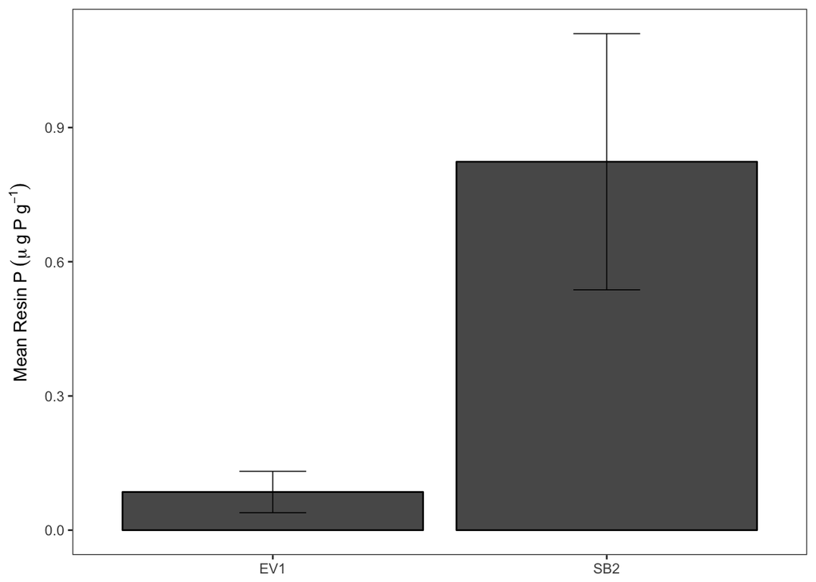

```r
ggplot(data = resinp.orgp.sum2, aes(x = Site, y = resin_mean)) + geom_bar(stat = "identity", colour = "black") + geom_errorbar(aes(ymax=resin_mean+resin_se, ymin=resin_mean-resin_se), width = 0.2, size = 0.3) + theme_bw() + theme(
  panel.grid.major = element_blank(),
  panel.grid.minor = element_blank(),
  axis.title.x = element_blank()) + ylab((expression(Mean~Resin~P~(mu~g~P~g^{-1}))))
```

## Organic P by Site

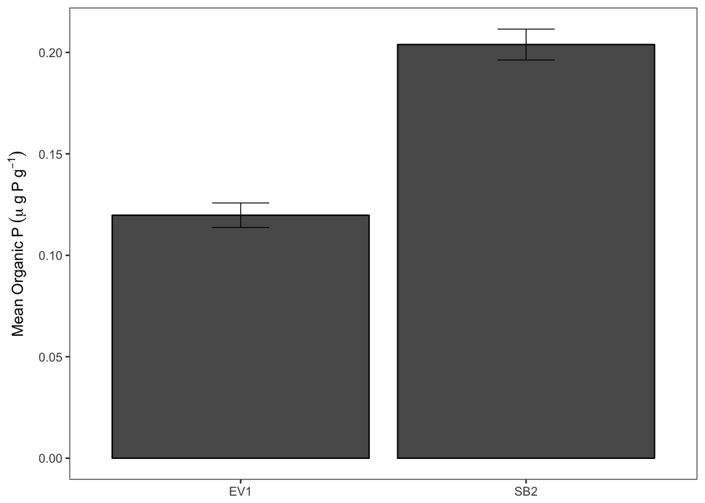

```r
ggplot(data = resinp.orgp.sum2, aes(x = Site, y = orgP_mean)) + geom_bar(stat = "identity", colour = "black") + geom_errorbar(aes(ymax=orgP_mean+orgP_se, ymin=orgP_mean-orgP_se), width = 0.2, size = 0.3) + theme_bw() + theme(
  panel.grid.major = element_blank(),
  panel.grid.minor = element_blank(),
  axis.title.x = element_blank()) + ylab((expression(Mean~Organic~P~(mu~g~P~g^{-1}))))
```

## Root phosphatase by Site

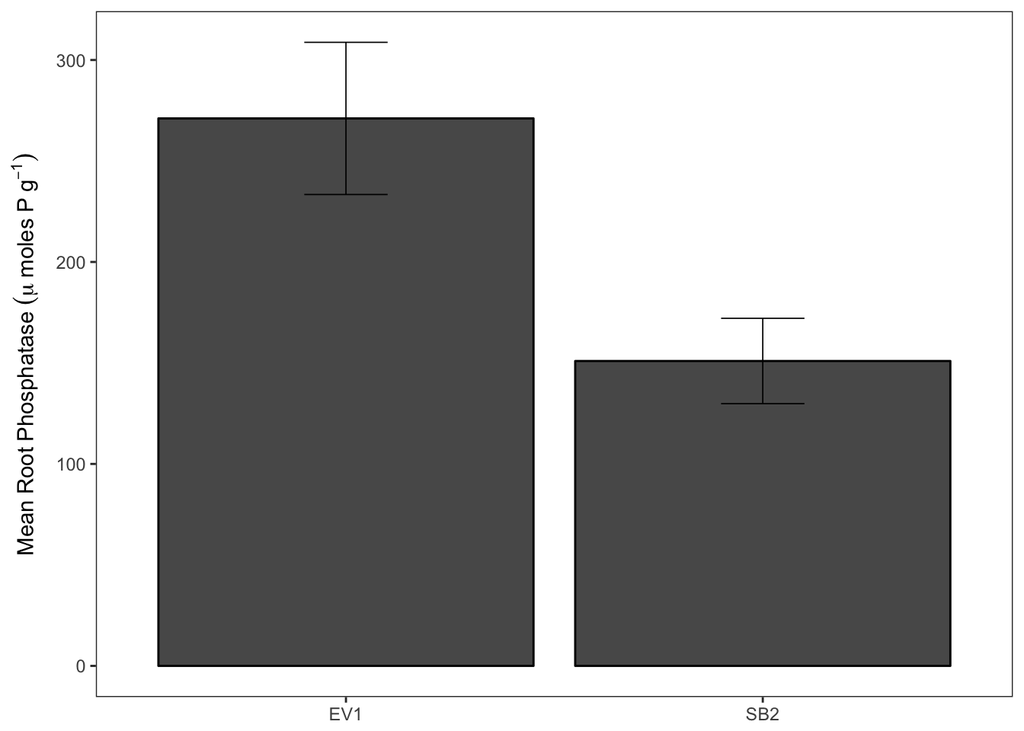

```r
ggplot(data = resinp.orgp.sum2, aes(x = Site, y = pase_mean)) + geom_bar(stat = "identity", colour = "black") + geom_errorbar(aes(ymax=pase_mean+pase_se, ymin=pase_mean-pase_se), width = 0.2, size = 0.3)  + theme_bw() + theme(
  panel.grid.major = element_blank(),
  panel.grid.minor = element_blank(),
  axis.title.x = element_blank()) + ylab((expression(Mean~Root~Phosphatase~(mu~moles~P~g^{-1}))))
```

## Comparisons

### Resin P and Organic P

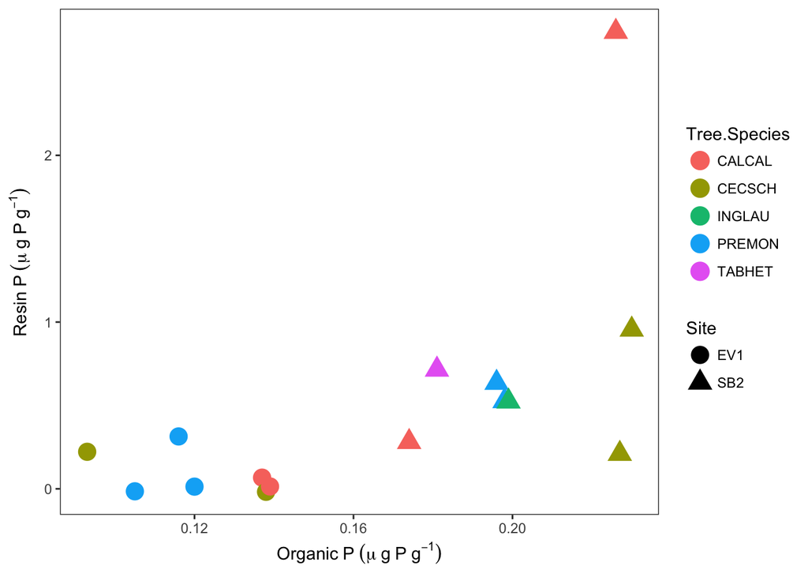

```r
ggplot(data =  bg.2017, aes(x = Total_OrganicP, y = ResinP, colour = Tree.Species, shape = Site)) + geom_point(size = 5.0) + theme_bw() + theme(
  panel.grid.major = element_blank(),
  panel.grid.minor = element_blank()) + ylab((expression(Resin~P~({mu}~g~P~g^{-1})))) +  xlab((expression(Organic~P~(mu~g~P~g^{-1}))))
```

### Ratio of Resin P:Organic P

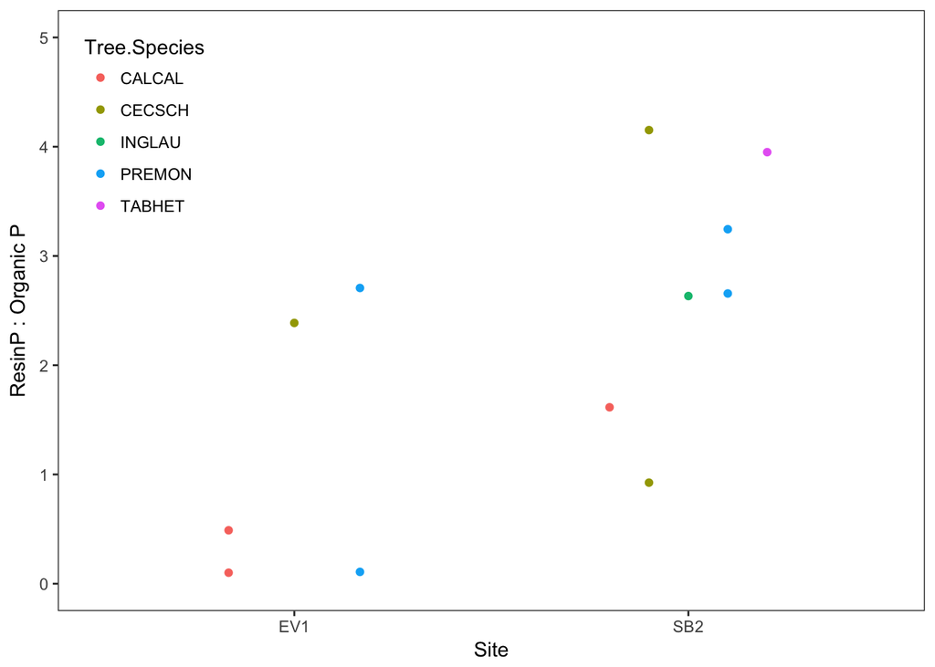

```r
bg.2017 <- bg.2017 %>%
  mutate(Ratio_ResinOrganic = ResinP / Total_OrganicP)

ggplot(data = bg.2017, aes(x = Site, y = Ratio_ResinOrganic, colour = Tree.Species)) + geom_point(position = position_dodge(0.5)) + scale_y_continuous(limits = c(0, 5)) + theme_bw() + theme(
  panel.grid.major = element_blank(),
  panel.grid.minor = element_blank()) + ylab("ResinP : Organic P") + theme(legend.position = c(0.1, 0.8))
```

### Root phosphatase x Resin P

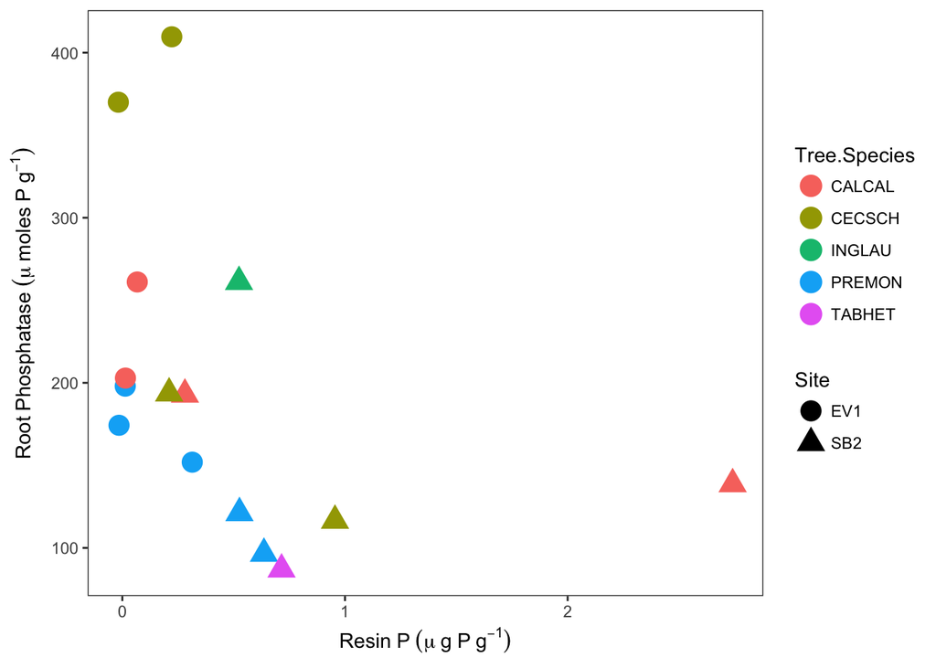

```r
ggplot(data =  bg.2017, aes(x = ResinP, y = Phosphatase, colour = Tree.Species, shape = Site)) + geom_point(size = 5.0) + theme_bw() + theme(
  panel.grid.major = element_blank(),
  panel.grid.minor = element_blank()) + ylab((expression(Root~Phosphatase~({mu}~moles~P~g^{-1})))) +  xlab((expression(Resin~P~(mu~g~P~g^{-1}))))
```

### Root phosphatase x Organic P

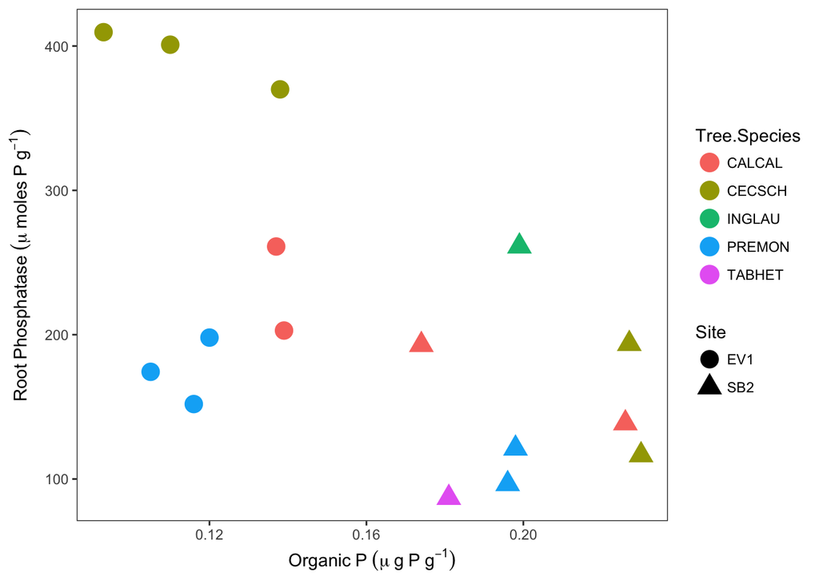

```r
ggplot(data =  bg.2017, aes(x = Total_OrganicP, y = Phosphatase, colour = Tree.Species, shape = Site)) + geom_point(size = 5.0) + theme_bw() + theme(
  panel.grid.major = element_blank(),
  panel.grid.minor = element_blank()) + ylab((expression(Root~Phosphatase~({mu}~moles~P~g^{-1})))) +  xlab((expression(Organic~P~(mu~g~P~g^{-1}))))
```

# Microbial Analysis

```r
microbial <- read.csv("~/Documents/LabStats/PR2_RemoteSensing/Microbial_SoilPase.csv", header = TRUE, stringsAsFactors = TRUE, na.strings = "NA")
```

## Summary Statistics

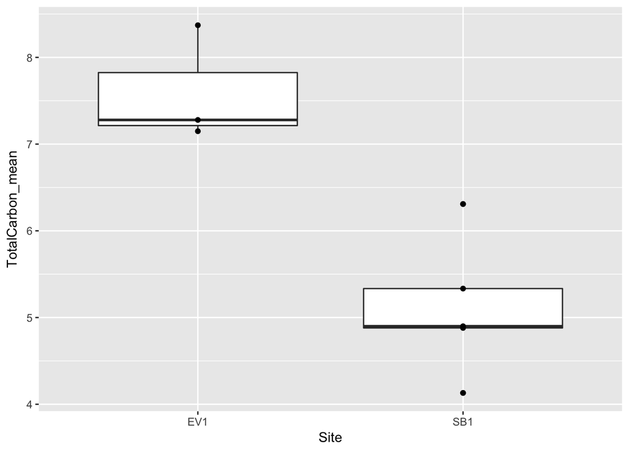

```r
library(plotrix)
microbial.sum <- microbial %>%
  group_by(Site, TreeSpecies) %>%
  summarise_at(c("TotalCarbon", "TotalNitrogen", "TC.TN", "NH4", "NO3", "PO4", "ExtC", "ExtN", "microbialC", "microbialN", "microbialP", "microbialCN", "TotalOrganicP", "ResinP", "Rootpase"), funs(mean, sd, std.error), na.rm = TRUE)
View(microbial.sum)

# Total Carbon
ggplot(data = microbial.sum, aes(x = Site, y = TotalCarbon_mean)) + geom_boxplot() + geom_point(aes(x = Site, y = TotalCarbon_mean))
```

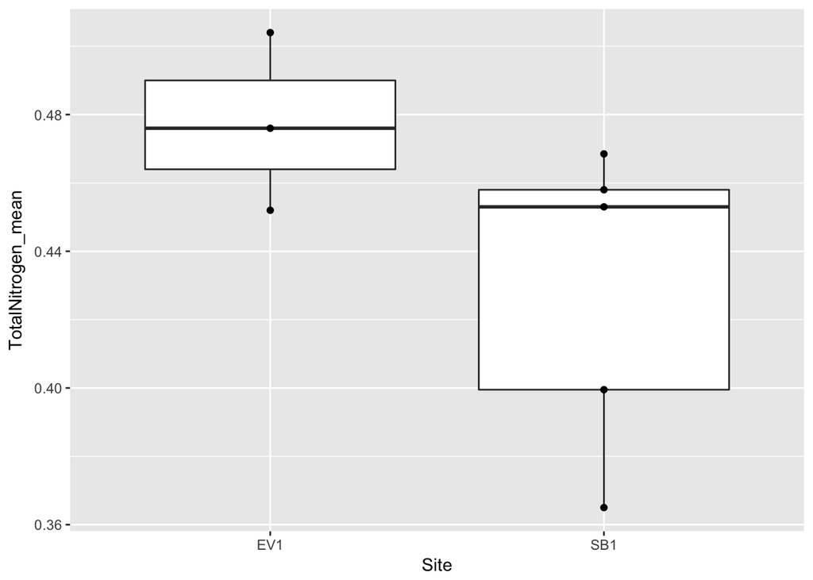

```r
# Total Nitrogen
ggplot(data = microbial.sum, aes(x = Site, y = TotalNitrogen_mean)) + geom_boxplot() + geom_point(aes(x = Site, y = TotalNitrogen_mean)) # see if root pase is higher with higher total N
```

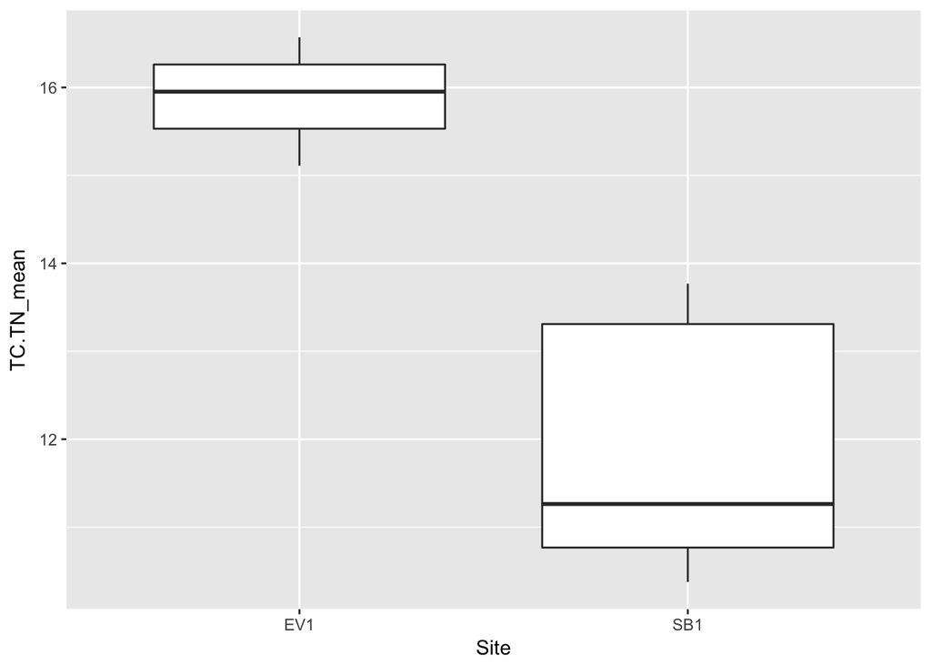

```r
# TC/TN mean
ggplot(data = microbial.sum, aes(x = Site, y = TC.TN_mean)) + geom_boxplot()
```

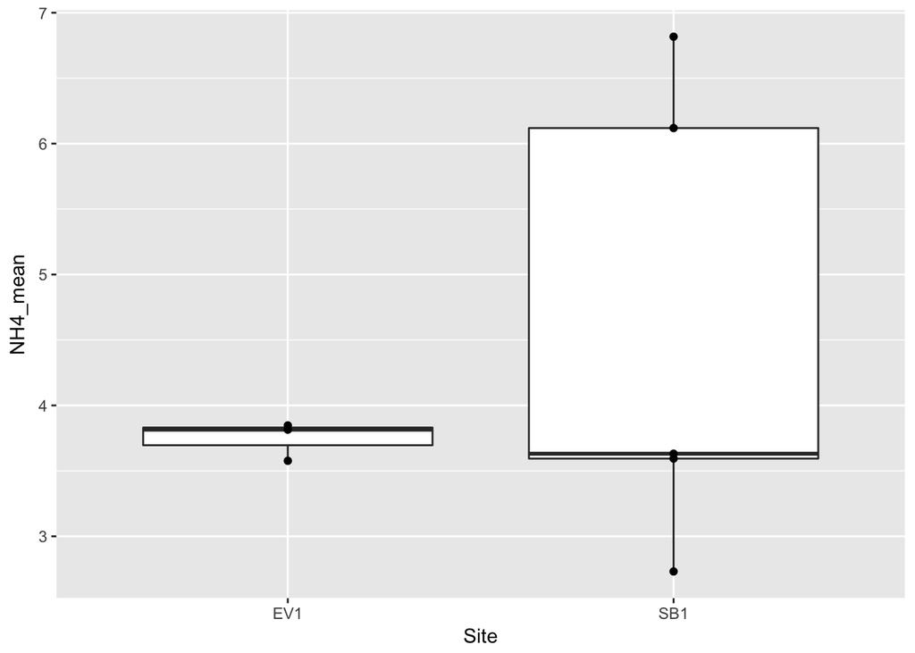

```r
# NH4 mean
ggplot(data = microbial.sum, aes(x = Site, y = NH4_mean)) + geom_boxplot() + geom_point(aes(x = Site, y = NH4_mean))
```

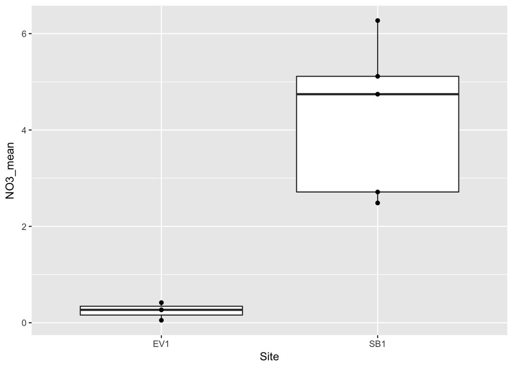

```r
# NO3 mean
ggplot(data = microbial.sum, aes(x = Site, y = NO3_mean)) + geom_boxplot() + geom_point(aes(x = Site, y = NO3_mean))
```

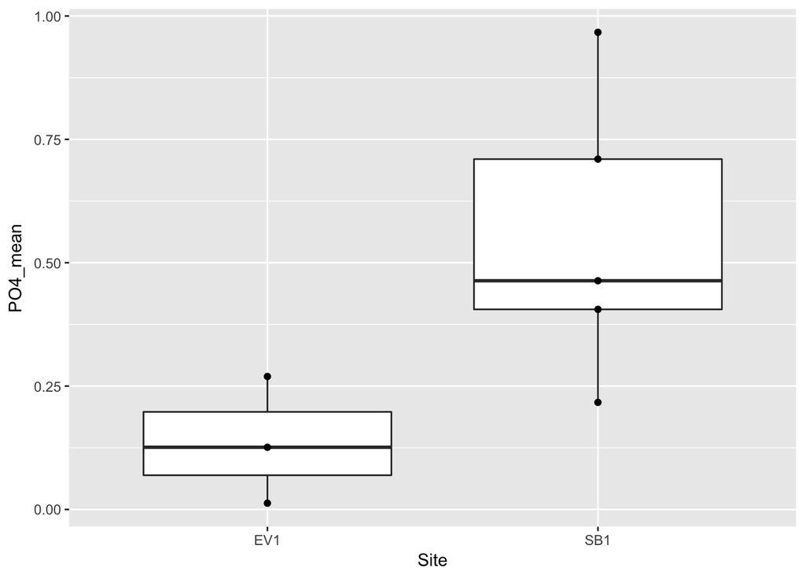

```r
# PO4 mean
ggplot(data = microbial.sum, aes(x = Site, y = PO4_mean)) + geom_boxplot() + geom_point(aes(x = Site, y = PO4_mean)) # consistent with resin P
```

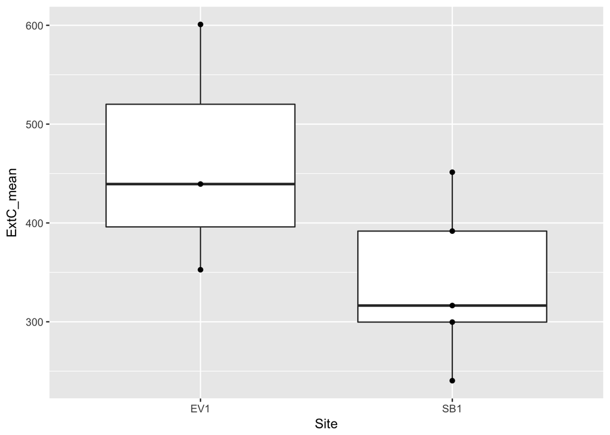

```r
# ExtC
ggplot(data = microbial.sum, aes(x = Site, y = ExtC_mean)) + geom_boxplot() + geom_point(aes(x = Site, y = ExtC_mean))
```

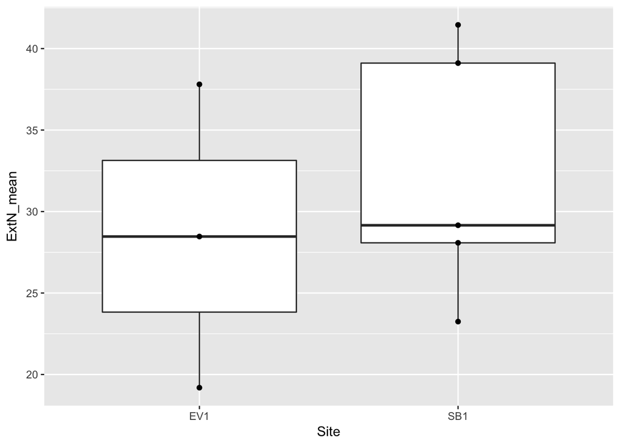

```r
# ExtN
ggplot(data = microbial.sum, aes(x = Site, y = ExtN_mean)) + geom_boxplot() + geom_point(aes(x = Site, y = ExtN_mean))
```

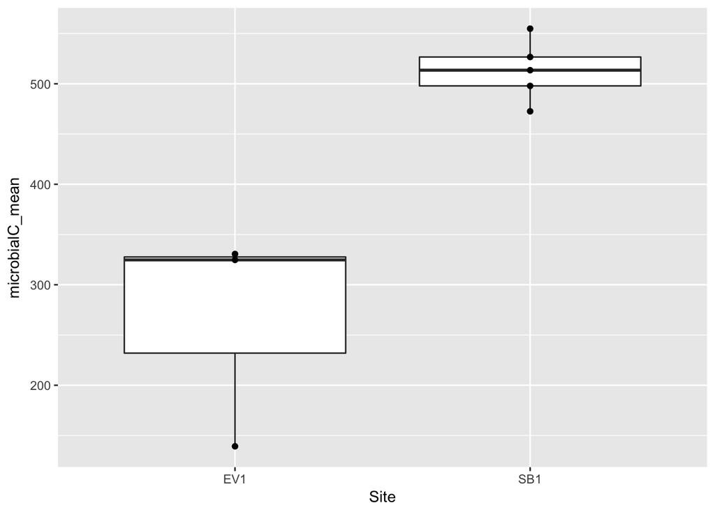

```r
# microbialC
ggplot(data = microbial.sum, aes(x = Site, y = microbialC_mean)) + geom_boxplot() + geom_point(aes(x = Site, y = microbialC_mean)) # consistent with lower amounts of organic phosphorus at each site
```

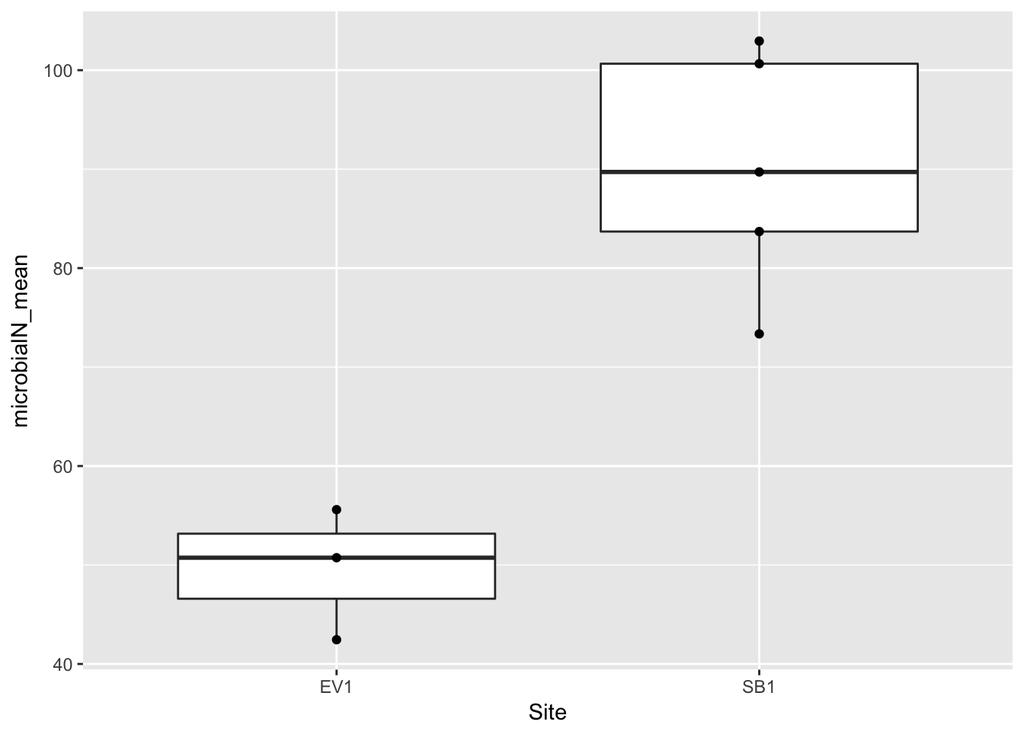

```r
# microbial N
ggplot(data = microbial.sum, aes(x = Site, y = microbialN_mean)) + geom_boxplot() + geom_point(aes(x = Site, y = microbialN_mean))
```

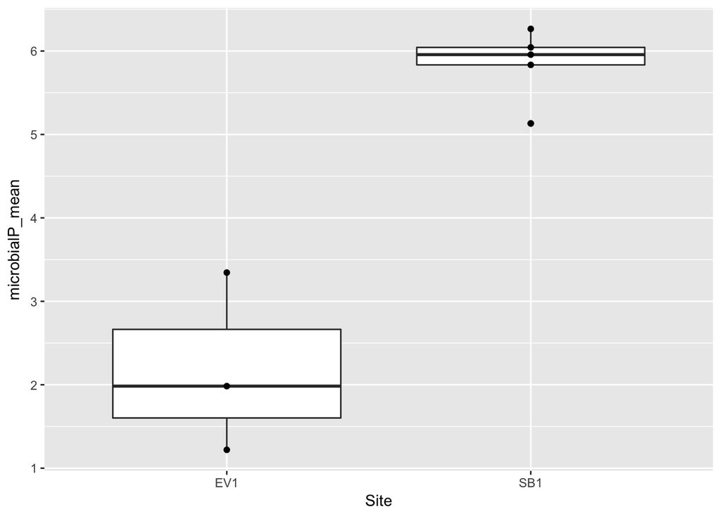

```r
# microbial P
ggplot(data = microbial.sum, aes(x = Site, y = microbialP_mean)) + geom_boxplot() + geom_point(aes(x = Site, y = microbialP_mean))
```

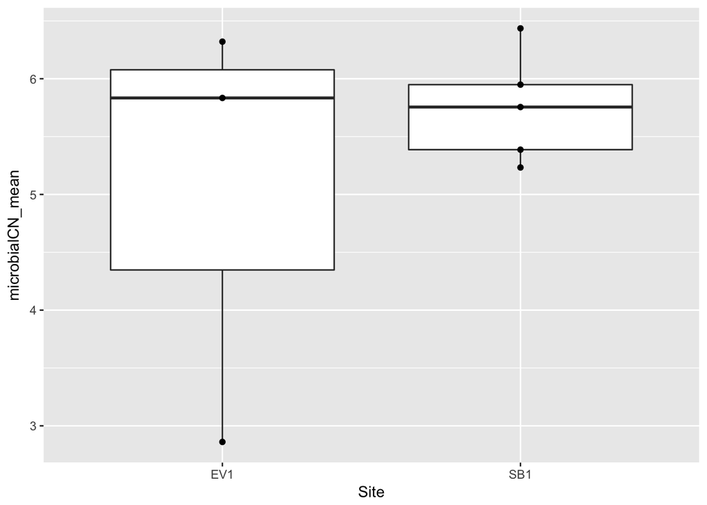

```r
# microbial CN
ggplot(data = microbial.sum, aes(x = Site, y = microbialCN_mean)) + geom_boxplot() + geom_point(aes(x = Site, y = microbialCN_mean))
```

## ANOVAs

```r
# Total Carbon
tc.aov <- aov(TotalCarbon ~ Site + TreeSpecies + Site:TreeSpecies, data = microbial)
summary(tc.aov) # Site
```

```
##                  Df Sum Sq Mean Sq F value Pr(>F)
## Site              1 25.268  25.268   8.513 0.0194 *
## TreeSpecies       4  4.133   1.033   0.348 0.8384
## Site:TreeSpecies  2  1.383   0.692   0.233 0.7973
## Residuals         8 23.744   2.968
## ---
## Signif. codes:  0 '***' 0.001 '**' 0.01 '*' 0.05 '.' 0.1 ' ' 1
```

```r
# Total Nitrogen
tn.aov <- aov(TotalNitrogen ~ Site + TreeSpecies + Site:TreeSpecies, data = microbial)
summary(tn.aov) # none
```

```
##                  Df  Sum Sq  Mean Sq F value Pr(>F)
## Site              1 0.01076 0.010764   1.288  0.289
## TreeSpecies       4 0.00775 0.001939   0.232  0.913
## Site:TreeSpecies  2 0.00960 0.004801   0.574  0.585
## Residuals         8 0.06688 0.008360
```

```r
# TC/TN
tctn.aov <- aov(TC.TN ~ Site + TreeSpecies + Site:TreeSpecies, data = microbial)
summary(tctn.aov)
```

```
##                  Df Sum Sq Mean Sq F value  Pr(>F)
## Site              1  63.55   63.55  24.785 0.00108 **
## TreeSpecies       4  13.53    3.38   1.319 0.34143
## Site:TreeSpecies  2   3.28    1.64   0.639 0.55260
## Residuals         8  20.51    2.56
## ---
## Signif. codes:  0 '***' 0.001 '**' 0.01 '*' 0.05 '.' 0.1 ' ' 1
```

```r
TukeyHSD(tctn.aov)
```

```
##   Tukey multiple comparisons of means
##     95% family-wise confidence level
##
## Fit: aov(formula = TC.TN ~ Site + TreeSpecies + Site:TreeSpecies, data = microbial)
##
## $Site
##              diff       lwr       upr     p adj
## SB1-EV1 -3.985875 -5.832125 -2.139625 0.0010816
##
## $TreeSpecies
##                     diff       lwr       upr     p adj
## CECSCH-CALCAL -1.7668875 -5.477822  1.944047 0.5119051
## INGLAU-CALCAL -2.1785625 -8.363453  4.006328 0.7432114
## PREMON-CALCAL -1.6160875 -5.327022  2.094847 0.5869254
## TABHET-CALCAL  0.8224375 -5.362453  7.007328 0.9890783
## INGLAU-CECSCH -0.4116750 -6.471606  5.648256 0.9991731
## PREMON-CECSCH  0.1508000 -3.347903  3.649503 0.9998629
## TABHET-CECSCH  2.5893250 -3.470606  8.649256 0.6024053
## PREMON-INGLAU  0.5624750 -5.497456  6.622406 0.9972111
## TABHET-INGLAU  3.0010000 -4.822337 10.824337 0.6851499
## TABHET-PREMON  2.4385250 -3.621406  8.498456 0.6495897
##
## $`Site:TreeSpecies`
##                             diff        lwr        upr     p adj
## SB1:CALCAL-EV1:CALCAL -3.2600000  -9.961016  3.4410162 0.6016374
## EV1:CECSCH-EV1:CALCAL -1.4598333  -7.576996  4.6573295 0.9836869
## SB1:CECSCH-EV1:CALCAL -5.3060000 -12.007016  1.3950162 0.1469707
## EV1:INGLAU-EV1:CALCAL         NA         NA         NA        NA
## SB1:INGLAU-EV1:CALCAL -5.8015000 -14.008535  2.4055352 0.2263686
## EV1:PREMON-EV1:CALCAL -0.6175000  -6.734663  5.4996628 0.9999742
## SB1:PREMON-EV1:CALCAL -6.1925000 -12.893516  0.5085162 0.0739753
## EV1:TABHET-EV1:CALCAL         NA         NA         NA        NA
## SB1:TABHET-EV1:CALCAL -2.8005000 -11.007535  5.4065352 0.8877280
## EV1:CECSCH-SB1:CALCAL  1.8001667  -4.316996  7.9173295 0.9455843
## SB1:CECSCH-SB1:CALCAL -2.0460000  -8.747016  4.6550162 0.9341583
## EV1:INGLAU-SB1:CALCAL         NA         NA         NA        NA
## SB1:INGLAU-SB1:CALCAL -2.5415000 -10.748535  5.6655352 0.9292899
## EV1:PREMON-SB1:CALCAL  2.6425000  -3.474663  8.7596628 0.7192319
## SB1:PREMON-SB1:CALCAL -2.9325000  -9.633516  3.7685162 0.7072517
## EV1:TABHET-SB1:CALCAL         NA         NA         NA        NA
```

[output cut: 14 more lines]

```
## SB1:INGLAU-EV1:INGLAU         NA         NA         NA        NA
## EV1:PREMON-EV1:INGLAU         NA         NA         NA        NA
## SB1:PREMON-EV1:INGLAU         NA         NA         NA        NA
## EV1:TABHET-EV1:INGLAU         NA         NA         NA        NA
## SB1:TABHET-EV1:INGLAU         NA         NA         NA        NA
## EV1:PREMON-SB1:INGLAU  5.1840000  -2.553667 12.9216670 0.2716022
## SB1:PREMON-SB1:INGLAU -0.3910000  -8.598035  7.8160352 1.0000000
## EV1:TABHET-SB1:INGLAU         NA         NA         NA        NA
## SB1:TABHET-SB1:INGLAU  3.0010000  -6.475668 12.4776679 0.9210090
## SB1:PREMON-EV1:PREMON -5.5750000 -11.692163  0.5421628 0.0790335
## EV1:TABHET-EV1:PREMON         NA         NA         NA        NA
## SB1:TABHET-EV1:PREMON -2.1830000  -9.920667  5.5546670 0.9566046
## EV1:TABHET-SB1:PREMON         NA         NA         NA        NA
## SB1:TABHET-SB1:PREMON  3.3920000  -4.815035 11.5990352 0.7581321
## SB1:TABHET-EV1:TABHET         NA         NA         NA        NA
```

```r
# Nitrogen and Phosphorus
nh4.aov <- aov(NH4 ~ Site + TreeSpecies + Site:TreeSpecies, data = microbial)
summary(nh4.aov) # none
```

```
##                  Df Sum Sq Mean Sq F value Pr(>F)
## Site              1  0.459   0.459   0.232  0.643
## TreeSpecies       4 15.976   3.994   2.022  0.184
## Site:TreeSpecies  2  0.278   0.139   0.070  0.933
## Residuals         8 15.804   1.975
```

```r
no3.aov <- aov(NO3 ~ Site + TreeSpecies + Site:TreeSpecies, data = microbial)
summary(no3.aov) # significant
```

```
##                  Df Sum Sq Mean Sq F value   Pr(>F)
## Site              1  69.15   69.15 111.642 5.62e-06 ***
## TreeSpecies       4   8.87    2.22   3.579   0.0589 .
## Site:TreeSpecies  2   8.40    4.20   6.781   0.0190 *
## Residuals         8   4.96    0.62
## ---
## Signif. codes:  0 '***' 0.001 '**' 0.01 '*' 0.05 '.' 0.1 ' ' 1
```

```r
TukeyHSD(no3.aov)
```

```
##   Tukey multiple comparisons of means
##     95% family-wise confidence level
##
## Fit: aov(formula = NO3 ~ Site + TreeSpecies + Site:TreeSpecies, data = microbial)
##
## $Site
##             diff      lwr      upr   p adj
## SB1-EV1 4.157875 3.250436 5.065314 5.6e-06
##
## $TreeSpecies
##                     diff        lwr       upr     p adj
## CECSCH-CALCAL  0.9082875 -0.9156517 2.7322267 0.4732455
## INGLAU-CALCAL  1.4695625 -1.5703362 4.5094612 0.4988424
## PREMON-CALCAL  1.3892875 -0.4346517 3.2132267 0.1535688
## TABHET-CALCAL -1.1584375 -4.1983362 1.8814612 0.6898840
## INGLAU-CECSCH  0.5612750 -2.4172053 3.5397553 0.9616371
## PREMON-CECSCH  0.4810000 -1.2386264 2.2006264 0.8628766
## TABHET-CECSCH -2.0667250 -5.0452053 0.9117553 0.2095311
## PREMON-INGLAU -0.0802750 -3.0587553 2.8982053 0.9999788
## TABHET-INGLAU -2.6280000 -6.4732015 1.2172015 0.2196072
## TABHET-PREMON -2.5477250 -5.5262053 0.4307553 0.0989787
##
## $`Site:TreeSpecies`
##                          diff        lwr        upr     p adj
## SB1:CALCAL-EV1:CALCAL  2.2960 -0.9975764  5.5895764 0.2376598
## EV1:CECSCH-EV1:CALCAL -0.1495 -3.1561101  2.8571101 0.9999999
## SB1:CECSCH-EV1:CALCAL  4.3255  1.0319236  7.6190764 0.0107364
## EV1:INGLAU-EV1:CALCAL      NA         NA         NA        NA
## SB1:INGLAU-EV1:CALCAL  4.6965  0.6627092  8.7302908 0.0218958
## EV1:PREMON-EV1:CALCAL -0.3665 -3.3731101  2.6401101 0.9998782
## SB1:PREMON-EV1:CALCAL  5.8535  2.5599236  9.1470764 0.0014938
## EV1:TABHET-EV1:CALCAL      NA         NA         NA        NA
## SB1:TABHET-EV1:CALCAL  2.0685 -1.9652908  6.1022908 0.5455241
## EV1:CECSCH-SB1:CALCAL -2.4455 -5.4521101  0.5611101 0.1314816
## SB1:CECSCH-SB1:CALCAL  2.0295 -1.2640764  5.3230764 0.3506954
## EV1:INGLAU-SB1:CALCAL      NA         NA         NA        NA
## SB1:INGLAU-SB1:CALCAL  2.4005 -1.6332908  6.4342908 0.3861288
## EV1:PREMON-SB1:CALCAL -2.6625 -5.6691101  0.3441101 0.0903825
## SB1:PREMON-SB1:CALCAL  3.5575  0.2639236  6.8510764 0.0332703
## EV1:TABHET-SB1:CALCAL      NA         NA         NA        NA
```

[output cut: 14 more lines]

```
## SB1:INGLAU-EV1:INGLAU      NA         NA         NA        NA
## EV1:PREMON-EV1:INGLAU      NA         NA         NA        NA
## SB1:PREMON-EV1:INGLAU      NA         NA         NA        NA
## EV1:TABHET-EV1:INGLAU      NA         NA         NA        NA
## SB1:TABHET-EV1:INGLAU      NA         NA         NA        NA
## EV1:PREMON-SB1:INGLAU -5.0630 -8.8660944 -1.2599056 0.0098779
## SB1:PREMON-SB1:INGLAU  1.1570 -2.8767908  5.1907908 0.9525337
## EV1:TABHET-SB1:INGLAU      NA         NA         NA        NA
## SB1:TABHET-SB1:INGLAU -2.6280 -7.2858204  2.0298204 0.4422854
## SB1:PREMON-EV1:PREMON  6.2200  3.2133899  9.2266101 0.0005149
## EV1:TABHET-EV1:PREMON      NA         NA         NA        NA
## SB1:TABHET-EV1:PREMON  2.4350 -1.3680944  6.2380944 0.3133031
## EV1:TABHET-SB1:PREMON      NA         NA         NA        NA
## SB1:TABHET-SB1:PREMON -3.7850 -7.8187908  0.2487908 0.0687222
## SB1:TABHET-EV1:TABHET      NA         NA         NA        NA
```

```r
po4.aov <- aov(PO4 ~ Site + TreeSpecies + Site:TreeSpecies, data = microbial)
summary(po4.aov) # Site
```

```
##                  Df Sum Sq Mean Sq F value Pr(>F)
## Site              1 0.5235  0.5235   7.470 0.0257 *
## TreeSpecies       4 0.3787  0.0947   1.351 0.3316
## Site:TreeSpecies  2 0.1408  0.0704   1.004 0.4082
## Residuals         8 0.5606  0.0701
## ---
## Signif. codes:  0 '***' 0.001 '**' 0.01 '*' 0.05 '.' 0.1 ' ' 1
```

```r
# Extractable C and N
extc.aov <- aov(ExtC ~ Site + TreeSpecies + Site:TreeSpecies, data = microbial)
summary(extc.aov) # site
```

```
##                  Df Sum Sq Mean Sq F value Pr(>F)
## Site              1  78135   78135  11.235 0.0101 *
## TreeSpecies       4  78105   19526   2.808 0.0999 .
## Site:TreeSpecies  2  53130   26565   3.820 0.0685 .
## Residuals         8  55636    6955
## ---
## Signif. codes:  0 '***' 0.001 '**' 0.01 '*' 0.05 '.' 0.1 ' ' 1
```

```r
extn.aov <- aov(ExtN ~ Site + TreeSpecies + Site:TreeSpecies, data = microbial)
summary(extn.aov) # tree species
```

```
##                  Df Sum Sq Mean Sq F value Pr(>F)
## Site              1   19.6   19.59   0.706 0.4252
## TreeSpecies       4  553.0  138.25   4.983 0.0259 *
## Site:TreeSpecies  2  283.4  141.68   5.107 0.0372 *
## Residuals         8  221.9   27.74
## ---
## Signif. codes:  0 '***' 0.001 '**' 0.01 '*' 0.05 '.' 0.1 ' ' 1
```

```r
# Microbial
microC.aov <- aov(microbialC ~ Site + TreeSpecies + Site:TreeSpecies, data = microbial)
summary(microC.aov) # Site
```

```
##                  Df Sum Sq Mean Sq F value  Pr(>F)
## Site              1 262089  262089  13.986 0.00571 **
## TreeSpecies       4  44547   11137   0.594 0.67687
## Site:TreeSpecies  2  29699   14849   0.792 0.48531
## Residuals         8 149915   18739
## ---
## Signif. codes:  0 '***' 0.001 '**' 0.01 '*' 0.05 '.' 0.1 ' ' 1
```

```r
microN.aov <- aov(microbialN ~ Site + TreeSpecies + Site:TreeSpecies, data = microbial)
summary(microN.aov) # Site
```

```
##                  Df Sum Sq Mean Sq F value  Pr(>F)
## Site              1   6627    6627  18.575 0.00258 **
## TreeSpecies       4    529     132   0.371 0.82330
## Site:TreeSpecies  2    736     368   1.032 0.39932
## Residuals         8   2854     357
## ---
## Signif. codes:  0 '***' 0.001 '**' 0.01 '*' 0.05 '.' 0.1 ' ' 1
```

```r
microP.aov <- aov(microbialP ~ Site + TreeSpecies + Site:TreeSpecies, data = microbial)
summary(microP.aov) # Site
```

```
##                  Df Sum Sq Mean Sq F value Pr(>F)
## Site              1  60.82   60.82  11.245  0.010 *
## TreeSpecies       4   4.35    1.09   0.201  0.931
## Site:TreeSpecies  2   1.97    0.99   0.182  0.837
## Residuals         8  43.27    5.41
## ---
## Signif. codes:  0 '***' 0.001 '**' 0.01 '*' 0.05 '.' 0.1 ' ' 1
```

```r
microCN.aov <- aov(microbialCN ~ Site + TreeSpecies + Site:TreeSpecies, data = microbial)
summary(microCN.aov)
```

```
##                  Df Sum Sq Mean Sq F value Pr(>F)
## Site              1  3.174   3.174   2.054  0.190
## TreeSpecies       4 12.876   3.219   2.083  0.175
## Site:TreeSpecies  2  8.896   4.448   2.878  0.114
## Residuals         8 12.363   1.545
```

Total carbon differs between EV1 and SB2 significantly (p< 0.05), with EV1 containing higher total carbon. Total nitrogen did not differ between site or tree species. TC/TN ratios were highly significant (p<0.01), with EV1 having higher TC/TN ratios. NO3 concentrations are significantly lower in EV1 than in SB2 with significant differences between tree species from each site. Similar to our results obtained using resin P, Bray 1 showed that PO4 was significantly (p <0.5) lower in EV1 than in SB2. Although extractable C was only significantly different between sites, extractable N was only significantly different between tree species(p<0.05), though with an interaction term (p<0.05). Microbial C,N, and P are significantly lower in EV1 than in SB2 (p<0.05), though microbial CN is not significantly different at both sites. (edit later for wording) ## Correlation Matrix

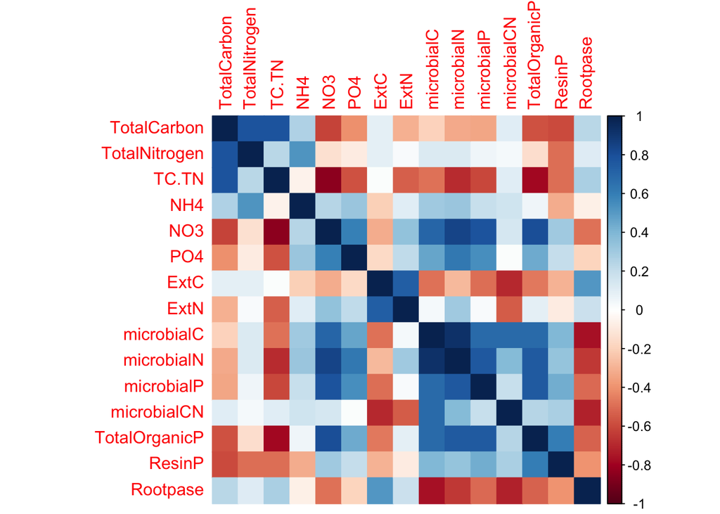

```r
library(corrplot)
micro2 <- microbial[-c(3), ] # removing data with resin P NA
microbial.cor <- cor(micro2[, c(4:18)]) # specifying which rows to create matrix from
M <- corrplot(microbial.cor, method = "color")
```

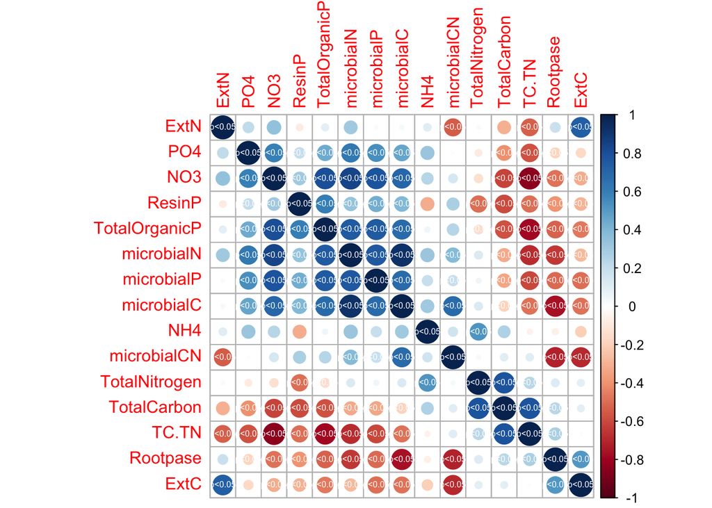

```r
res1 <- cor.mtest(microbial.cor, conf.level = 0.95)
res2 <- cor.mtest(microbial.cor, conf.level = 0.99)

# plot
corrplot(M, p.mat = res1$p,insig = "label_sig", pch.col = "white", pch = "p<0.05", pch.cex = 0.5, order = "AOE")
```